# ANALYSIS OF DATA FROM BLUEPRINT FOREX APP

## By Wofai Alfred Eyong

### Data Analyst; Blueprint Fintech Solutions ltd.

# Introduction

Blueprint Fintech Solutions ltd is a Lagos, Nigeria-based company in the foreign exchange market; a global marketplace where banks, institutions and investors, place trades and calls on different currency pairs. This company created its first software application: THE BLUEPRINT FOREX APP, which is a place where subscribers can receive trading calls, signals and information to aid trading the financial market. With over 300 subscribers after the app launch, trade calls were given over an 80 day period. All generated information from the company spanning across several variables was collated to curate the 2 datasets which were merged and analysed. The dataset contains information on about 15 variables, all of which are focused on the trade calls given from the app and their outcomes. The variables analysed include:

**Date:** Date of record creation in table 1. It corresponds to the open date.

**Pairs:** Currency pairs traded.

**Trade:** Trade calls (Buy or Sell).

**Open:** Date trade was opened.

**Close:** Date trade was closed.

**result:** Trade outcome (Successful or Unsuccessful).

**lot_size:** Lot size used for trade.

**no_of_pips_won:** Number of pips won after trade was closed.

**no_of_pips_lost:** Number of pips lost after trade was closed.

**amt_won:** Amount in dollars won after trade was closed.

**amt_lost:** Amount in dollars lost after trade was closed.

**Index_day:** Trade day count (From monday to friday only)

**Date:** Date of record creation in table 2.

**no_of_trades_entered:** Number of trades entered on a particular day.

**no_of_trades_closed:** Number of trades closed on a particular day.

# ANALYSIS AND VISUALIZATION

## What currency pair was most traded?

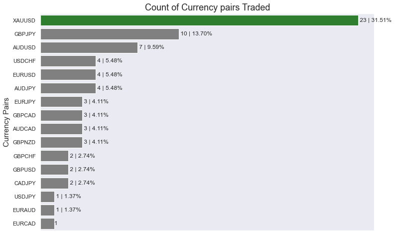

The XAUUSD currency pair was most traded during the 80-days trade period. It accounted for 31.5% of all trades or 23 trades. The GBPJPY pair was next at 13.7% or 10 trades. This is over 50 percent less that the most traded pair.

## What trades were most entered: Buys or sells?

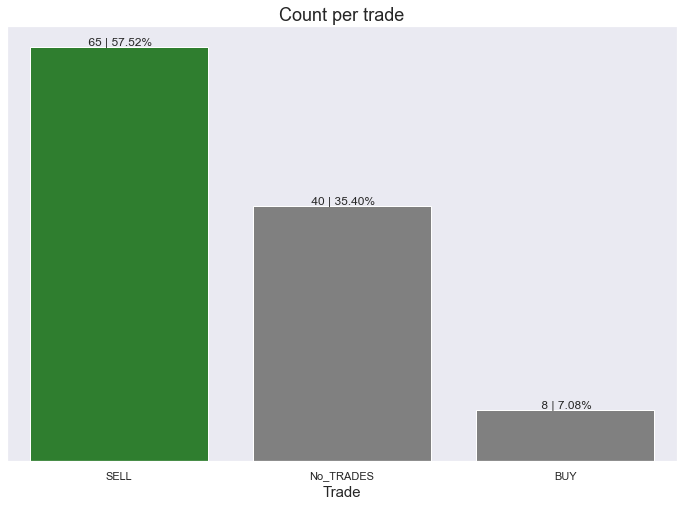

Over 57% of trades called were sell trades. About 35% of the time, trades were not called. Buy trades were called only 7% of the whole time.

## What was the average trade length per day?

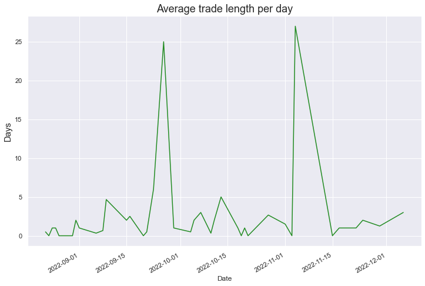

Generally, an average trade length of 2 days was observed during the 80 days trade period. Upon further analysis, i observed that although the 'in-a-trade' duration ranged between 0 and 5, two spikes showed two trades which were drawn out for about 25-30days.